# Plotting with miamiplot

Julie White

Feb. 24, 2021

# Introduction

This document acts as a tutorial for using the miamiplot package to create Miami plots for GWAS or EWAS results. Use `?FunctionName` in the R console to get the complete documentation of a given function.  
Packages used in this vignette:

```r
library(miamiplot)
library(dplyr)
library(ggplot2)
requireNamespace("RColorBrewer", quietly = TRUE)
```

The `miamiplot` package includes a data.frame called `gwas_results` with simulated results from GWAS of 30,000 SNPs each on 22 chromosomes.

```r
str(gwas_results)
```

```
#> 'data.frame':    60000 obs. of  8 variables:
#>  $ rsid : chr  "rs1" "rs2" "rs3" "rs4" ...
#>  $ chr  : num  1 1 1 1 1 1 1 1 1 1 ...
#>  $ pos  : int  1 2 3 4 5 6 7 8 9 10 ...
#>  $ beta : num  -0.00446 -0.00274 -0.01856 0.01167 -0.05318 ...
#>  $ se   : num  0.00977 0.01418 0.01676 0.01011 0.0322 ...
#>  $ tstat: num  -0.456 -0.194 -1.107 1.155 -1.652 ...
#>  $ pval : num  0.6482 0.8465 0.2683 0.2481 0.0986 ...
#>  $ study: chr  "A" "A" "A" "A" ...
```

# Plotting

## Assigning values to to the upper and lower sections of the plot

Say you wanted to plot the GWAS from study A and wanted to separate the plot by beta values, with the variants with positive beta values in the upper plot. While we’re at it, we can specify y-axis label names.

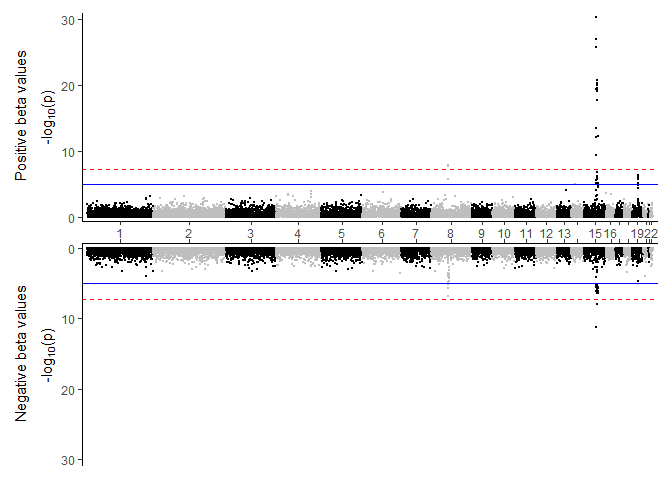

```r
ggmiami(data = gwas_results[which(gwas_results$study == "A"),],
        split_by = "beta", split_at = 0, p = "pval",
        upper_ylab = "Positive beta values",
        lower_ylab = "Negative beta values")
```

It seems like most of the lower p-value SNPs in the peak on chromosome 15 have positive beta values.  
Say instead you wanted to plot the results from study “A” in the upper plot and study “B” in the lower plot.

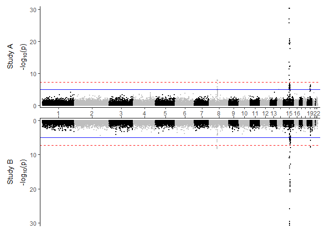

```r
ggmiami(data = gwas_results, split_by = "study", split_at = "A", p = "pval",
        upper_ylab = "Study A", lower_ylab = "Study B")
```

## Changing the significance lines

The suggestive and genome-wide significance lines can either be turned off or given different p-values. In this example we’ll turn off the suggestive line and plot the genome-wide line at a very small value: 5e-15.

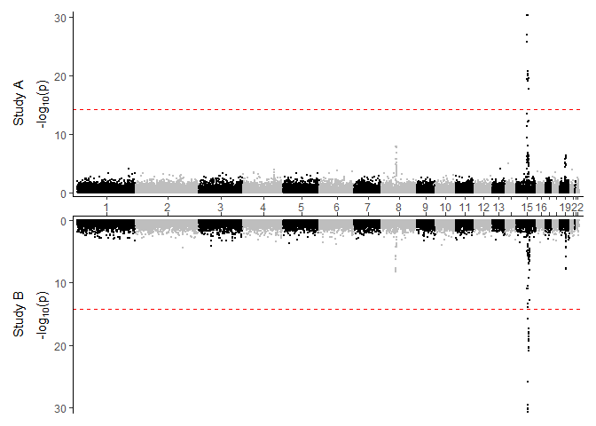

```r
ggmiami(data = gwas_results, split_by = "study", split_at = "A", p = "pval",
        upper_ylab = "Study A",lower_ylab = "Study B", suggestive_line = NULL,
        genome_line = 5e-15)
```

## Changing colors

The default chromosome colors are alternating black and grey. If you’d prefer to supply your own alternating colors, you can do so using color names, e.g. `chr_colors = c("blue", "orange")`, hexidecimal names, e.g. `chr_colors = c("#d8b365", "#5ab4ac")`, or a list of colors equal to the number of chromosomes in your plot.  
Here, using 22 colors produced by extending the “Paired” RColorBrewer palette.

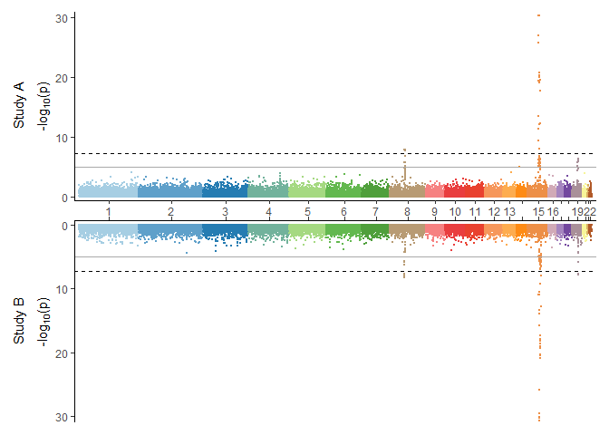

```r
mycolors <- grDevices::colorRampPalette(RColorBrewer::brewer.pal(12,
                                                                 "Paired"))(22)

ggmiami(data = gwas_results, split_by = "study", split_at = "A", p = "pval",
        upper_ylab = "Study A", lower_ylab = "Study B", chr_colors = mycolors,
        genome_line_color = "black", suggestive_line_color = "#A9A9A9")
```

You can also specify different colors for the top and bottom plot, provided that you make `chr_colors` NULL and you specify both `upper_chr_colors` and `lower_chr_colors`. You can use color names or hexidecimal names, as above.

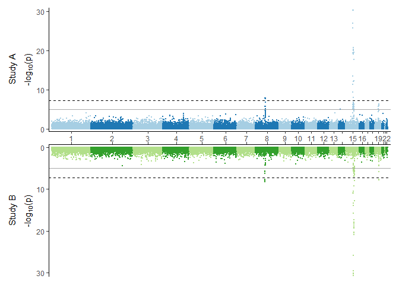

```r
my_upper_colors <- RColorBrewer::brewer.pal(4, "Paired")[1:2]
my_lower_colors <- RColorBrewer::brewer.pal(4, "Paired")[3:4]

ggmiami(data = gwas_results, split_by = "study", split_at = "A", p = "pval",
        upper_ylab = "Study A", lower_ylab = "Study B", chr_colors = NULL,
        upper_chr_colors = my_upper_colors, lower_chr_colors = my_lower_colors,
        genome_line_color = "black", suggestive_line_color = "#A9A9A9")
```

## Adding labels

To simply label the top 5 hits on each plot, all you need to do is supply the name of the column from which we should draw the lables. Here, we’ll label the top 5 from each plot section with the rsid.

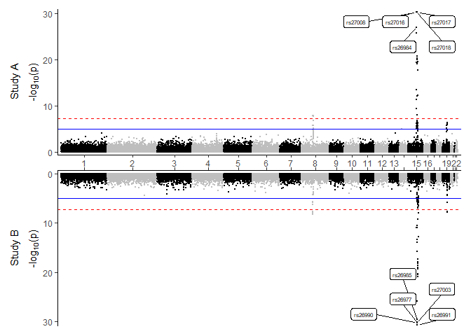

```r
ggmiami(data = gwas_results, split_by = "study", split_at = "A", p = "pval",
        upper_ylab = "Study A", lower_ylab = "Study B",
        hits_label_col = "rsid")
```

You can also label based on two columns, and change the number of labels, though this can get a bit messy:

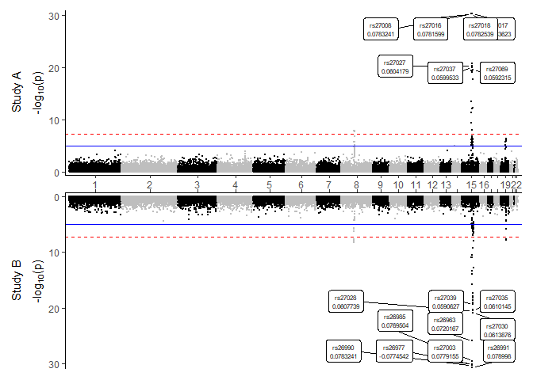

```r
ggmiami(data = gwas_results, split_by = "study", split_at = "A", p = "pval",
        upper_ylab = "Study A", lower_ylab = "Study B",
        hits_label_col = c("rsid", "beta"), top_n_hits = 10)
```

If you would instead like to supply a list of which items to label, you can use `hits_label` to supply the list, and `hits_label_col` to specify where these values will be found.

```r
ggmiami(data = gwas_results, split_by = "study", split_at = "A", p = "pval",
        upper_ylab = "Study A", lower_ylab = "Study B",
        hits_label = c("rs19142", "rs27017", "rs19103", "rs26991", "rs29240"),
        hits_label_col = "rsid")
```

```
#> The column {rsid} has special characters in it. This function only respects exact matches, so your labels may be incorrect. Please consider removing the special characters from this column or providing exact matches.
#> The column {rsid} has special characters in it. This function only respects exact matches, so your labels may be incorrect. Please consider removing the special characters from this column or providing exact matches.
```

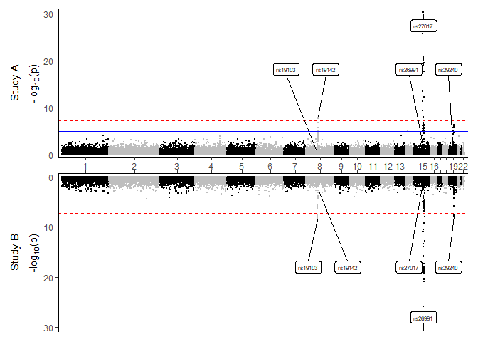

### Custom labels

Say you wanted to be more specific and provide your own dataframe containing the labelling information. This requires a little front-end work on your part, but gives you more control in case the above two options aren’t producing what you want.  
First, it’s helpful to have access to the actual data being plotted, so that you don’t have to go about calculating relative genomic position on your own. We can do this using the `prep_miami_data` function from this package.

```r
plot_data <- prep_miami_data(data = gwas_results, split_by = "study",
                             split_at = "A", p = "pval")
```

Next, say we wanted to identify top peak from each chromosome and plot the five with the lowest p-values, while labelling them with rsid and beta value.

```r
# Study A
studyA_labels <- plot_data$upper %>%
  group_by(chr) %>%
  arrange(desc(logged_p)) %>%
  slice(1) %>%
  ungroup() %>%
  mutate(label = paste0(rsid, "\n", beta)) %>%
  select(rel_pos, logged_p, label) %>%
  arrange(desc(logged_p)) %>%
  slice(1:5)

# Study B
studyB_labels <- plot_data$lower %>%
  group_by(chr) %>%
  arrange(desc(logged_p)) %>%
  slice(1) %>%
  ungroup() %>%
  mutate(label = paste0(rsid, "\n", beta)) %>%
  select(rel_pos, logged_p, label) %>%
  arrange(desc(logged_p)) %>%
  slice(1:5)
```

Now for the plot.

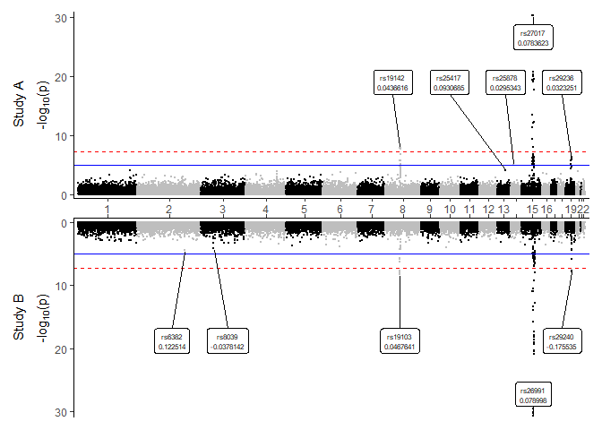

```r
ggmiami(data = gwas_results, split_by = "study", split_at = "A", p = "pval",
        upper_ylab = "Study A", lower_ylab = "Study B",
        upper_labels_df = studyA_labels, lower_labels_df = studyB_labels)
```

You can also specify labels for only one plot. But you will get an error if you try to mix label methods.

```r
ggmiami(data = gwas_results, split_by = "study", split_at = "A", p = "pval",
        upper_ylab = "Study A", lower_ylab = "Study B",
        upper_labels_df = studyA_labels, hits_label_col = c("rsid", "beta"))
```

```
#> Error in ggmiami(data = gwas_results, split_by = "study", split_at = "A", : You have specified both hits_label_col and a *_labels_df. This
#>          package does not know how to use both information simultaneously.
#>          Please only use one method for labelling: either hits_label_col (with
#>          or without hits_label), or *_labels_df.
```

## Highlighting SNPs

If you wanted to highlight specific points, you can do so. For the upper plot I’m going to highlight everything withih 100 bp of the two genome-wide significant peaks.

```r
# Get the position of the two peaks +- 100 bp.
studyA_highlight_pos <- plot_data$upper %>%
  filter(pval < 5e-8) %>%
  group_by(chr) %>%
  filter(pval == min(pval)) %>%
  summarise(start = rel_pos - 100, end = rel_pos + 100) %>%
  select(-chr) %>%
  apply(., 1, function(x) x["start"]:x["end"]) %>%
  as.vector()

# Find which rsids match these SNPs
studyA_highlight_rsid <- plot_data$upper %>%
  mutate(in_peak = case_when(rel_pos %in% studyA_highlight_pos ~ "Yes",
                             TRUE ~ "No")) %>%
  filter(in_peak == "Yes") %>%
  select(rsid)
```

Add to plot.

```r
ggmiami(data = gwas_results, split_by = "study", split_at = "A", p = "pval",
        upper_ylab = "Study A", lower_ylab = "Study B",
        upper_labels_df = studyA_labels, lower_labels_df = studyB_labels,
        upper_highlight = studyA_highlight_rsid$rsid,
        upper_highlight_col = "rsid")
```

```
#> The column {rsid} has special characters in it.
#>             This function only respects exact matches, so your highlights
#>             may be incorrect. Please consider removing the special
#>             characters from this column or providing exact matches.
```

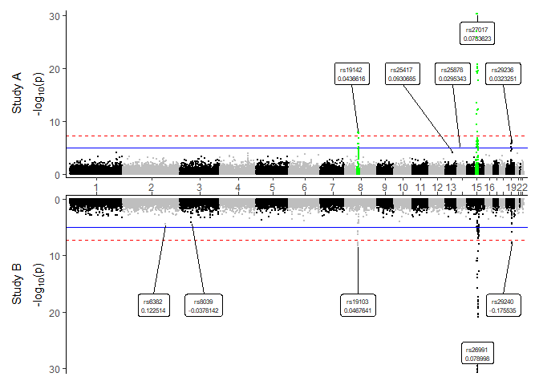

You can also change the highlighting color with either names or hex codes using `upper_highlight_color` and `lower_highlight_color`, much like what was done when changing the chromosome colors.

```r
studyA_highlight_rsid <- plot_data$upper %>%
  mutate(in_peak = case_when(rel_pos %in% studyA_highlight_pos ~ "Yes",
                             TRUE ~ "No")) %>%
  filter(in_peak == "Yes") %>%
  arrange(logged_p) %>%
  mutate(color = rep(c("magenta", "green"), length.out = n())) %>%
  select(rsid, logged_p, color)
```

Add to plot

```r
ggmiami(data = gwas_results, split_by = "study", split_at = "A", p = "pval",
        upper_ylab = "Study A", lower_ylab = "Study B",
        upper_labels_df = studyA_labels, lower_labels_df = studyB_labels,
        upper_highlight = studyA_highlight_rsid$rsid,
        upper_highlight_col = "rsid",
        upper_highlight_color = studyA_highlight_rsid$color)
```

```
#> The column {rsid} has special characters in it.
#>             This function only respects exact matches, so your highlights
#>             may be incorrect. Please consider removing the special
#>             characters from this column or providing exact matches.
```

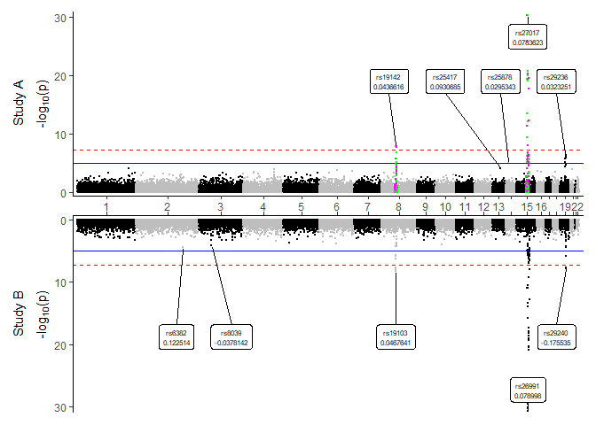

## Saving the plot

Since the plot produced is a patchwork of ggplot2 objects, it can be saved using ggsave.

```r
p <- ggmiami(data = gwas_results, split_by = "study", split_at = "A",
             p = "pval", upper_ylab = "Study A", lower_ylab = "Study B",
             upper_labels_df = studyA_labels, lower_labels_df = studyB_labels,
             upper_highlight = studyA_highlight_rsid$rsid,
             upper_highlight_col = "rsid", upper_highlight_color = "magenta")
```

```
#> The column {rsid} has special characters in it.
#>             This function only respects exact matches, so your highlights
#>             may be incorrect. Please consider removing the special
#>             characters from this column or providing exact matches.
```

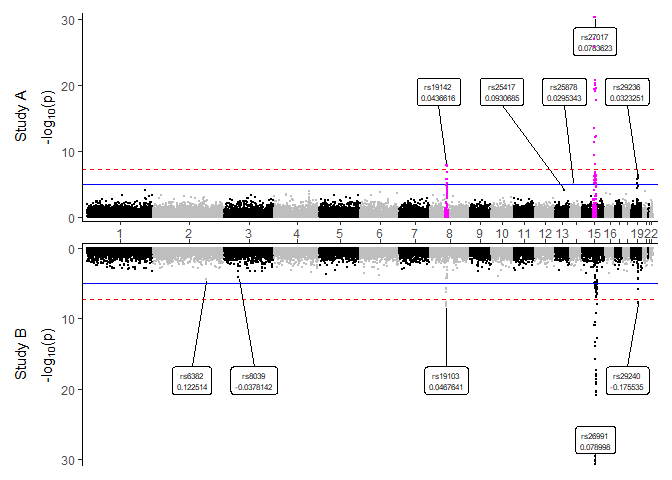

```r
# ggsave(p, filename = "ExampleMiamiPlot.png", device = "png", width = 8,
       # height = 6, units = "in")
```

# A few notes

- The default values for chromosome, position and p-value are `chr`, `pos`, and `p`, respectively. If you’re creating a miami plot and your column names are different, you’ll have to pass the column names to the `chr =`, `pos =`, and `p =` arguments. See help(ggmiami) for details.
- The chromosome column must be numeric. If you have “X,” “Y,” or “MT” chromosomes, you’ll need to rename these 23, 24, 25, etc. You can modify the source code (e.g. `fix(ggmiami)`) to change the line designating the axis tick labels in the upper plot `labels = plot_data$axis$chr` to set this to whatever you’d like it to be.